# 1. Exploración inicial de CERT r4.2 para detección de amenaza interna

## 3.3. Dataset Email (CERT r4.2) - muestreo preliminar

Volumen aproximado: ~1.3GB. En esta fase se utiliza una muestra por chunks para obtener señal exploratoria con diversidad temporal sin sobrecarga de memoria.

```python
# 9.1 Cargamos la preliminar por muestreo aleatorio de chunks
# Objetivo: obtener señal exploratoria representativa sin saturar memoria (email.csv ~1.3GB)
import random
email_path = DATASETS['email']
EMAIL_TARGET_ROWS = 200000 # Tamaño objetivo de la muestra para EDA
EMAIL_CHUNK_SIZE = 50000   # Tamaño de cada chunk de lectura (balance RAM/velocidad)

# Primera pasada: identificamos índices de chunks disponibles
chunks = []
chunk_indices = []
for i, chunk in enumerate(pd.read_csv(email_path, chunksize=EMAIL_CHUNK_SIZE, parse_dates=['date'])):
    chunk_indices.append(i)

# ....aleatoriamente 4-5 chunks para obtener ~200-250k filas
# Seleccion aleatoria de chunks para preservar diversidad temporal y evitar sesgo de orden
n_chunks_needed = max(4, EMAIL_TARGET_ROWS // EMAIL_CHUNK_SIZE)
selected_indices = sorted(random.sample(chunk_indices, min(n_chunks_needed, len(chunk_indices))))
print(f'Total chunks disponibles: {len(chunk_indices)}, seleccionados: {len(selected_indices)} índices: {selected_indices}')

# Segunda pasada: cargamos solo los chunks seleccionados
chunks = []
for i, chunk in enumerate(pd.read_csv(email_path, chunksize=EMAIL_CHUNK_SIZE, parse_dates=['date'])):
    if i in selected_indices:
        chunks.append(chunk)

# Concatenacio y validacion de la muestra resultante
df_email = pd.concat(chunks, ignore_index=True)
print(f'Muestra email cargada (chunks aleatorios): {df_email.shape}')
print(f'Columnas email: {df_email.columns.tolist()}')
print(f'Rango temporal: {df_email["date"].min()} a {df_email["date"].max()}')
df_email.head()
```

```
Total chunks disponibles: 53, seleccionados: 4 índices: [35, 38, 43, 48]
Muestra email cargada (chunks aleatorios): (200000, 11)
Columnas email: ['id', 'date', 'user', 'pc', 'to', 'cc', 'bcc', 'from', 'size', 'attachments', 'content']
Rango temporal: 2010-11-16 18:06:26 a 2011-04-08 09:32:35
```

|  | id | date | user | pc | to | cc | bcc | from | size | attachments | content |
| --- | --- | --- | --- | --- | --- | --- | --- | --- | --- | --- | --- |
| 0 | {M7L1-K8JG91XH-6837KMSQ} | 2010-11-16 18:06:26 | RAW0915 | PC-2113 | Amena.Karyn.Christian@dtaa.com;Jade.Maris.Cole... | Hashim.Damon.Hebert@dtaa.com;Lillith.Adena.Mat... | NaN | Robert.Ali.Webb@dtaa.com | 35941 | 2 | at forced some exceeding put game throw instea... |
| 1 | {R3M3-H6DM81NV-1125TRPQ} | 2010-11-16 18:06:41 | WNB0908 | PC-0094 | Cedric.Herrod.Gilliam@dtaa.com;Xenos.Hayden.Ga... | Leonard.Uriel.Ramos@dtaa.com | NaN | Wing.Noah.Bonner@dtaa.com | 20975 | 2 | replace whom news 10 attributed should quarter... |
| 2 | {E3R9-Y1MI97ME-0619RYYH} | 2010-11-16 18:06:43 | NGC0058 | PC-7558 | Jackson.Linus.Wilkerson@dtaa.com | NaN | Nadine.Gay.Cross@dtaa.com | Nadine.Gay.Cross@dtaa.com | 17854 | 0 | 78 against 875 losses owned and wanted hamilto... |
| 3 | {B9C4-O1TB21HY-7694UBWE} | 2010-11-16 18:07:31 | SRS0231 | PC-3684 | NGC9431@optonline.net | NaN | NaN | Solomon_Sandra@gmail.com | 21955 | 1 | outermost remains ritual blocks struck portion... |
| 4 | {R6Y1-R6RF98DZ-0866BUGG} | 2010-11-16 18:07:40 | JMH0543 | PC-7345 | Kimberley.Roary.Maldonado@dtaa.com | Philip.Travis.Hartman@dtaa.com;Tara.Alma.Potts... | NaN | Jermaine.Mannix.Hansen@dtaa.com | 21184 | 0 | although often critic recreate shine michigan ... |

```
<class 'pandas.core.frame.DataFrame'>
RangeIndex: 200000 entries, 0 to 199999
Data columns (total 11 columns):
 #   Column       Non-Null Count   Dtype
---  ------       --------------   -----
 0   id           200000 non-null  object
 1   date         200000 non-null  datetime64[ns]
 2   user         200000 non-null  object
 3   pc           200000 non-null  object
 4   to           200000 non-null  object
 5   cc           75784 non-null   object
 6   bcc          32063 non-null   object
 7   from         200000 non-null  object
 8   size         200000 non-null  int64
 9   attachments  200000 non-null  int64
 10  content      200000 non-null  object
dtypes: datetime64[ns](1), int64(2), object(8)
memory usage: 16.8+ MB
Nulos en email (muestra):
cc     124216
bcc    167937
dtype: int64
Fecha mínima (muestra): 2010-11-16 18:06:26
Fecha máxima (muestra): 2011-04-08 09:32:35
```

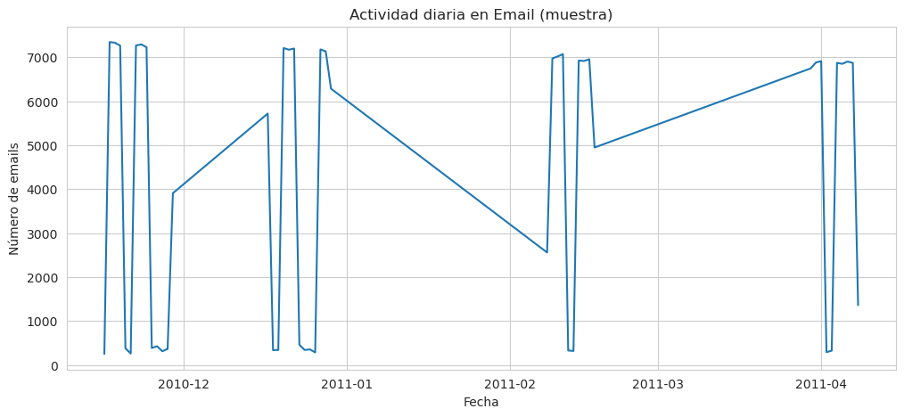

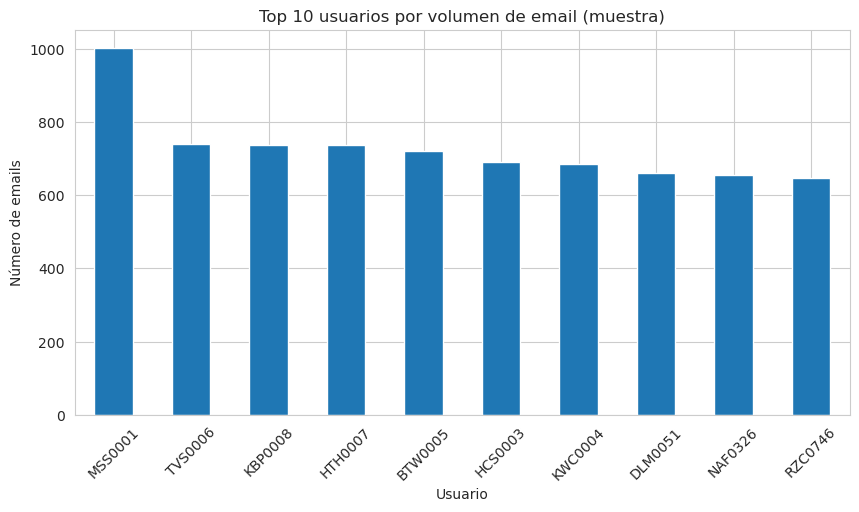

```
Resumen exploración Email (muestra):
  - Registros en muestra: 200000
  - Usuarios únicos (muestra): 914
  - Rango temporal (muestra): 2010-11-16 18:06:26 a 2011-04-08 09:32:35
  - Con adjuntos (muestra): 200000
  - Con destinatario TO (muestra): 200000
```

```python
# 9.2 Calidad, temporalidad y actividad preliminar
# Validacio estructural: tipos de datos, memoria y conteo de no-nulos
df_email.info()
report_nulls(df_email, title='Nulos en email (muestra):')

# Rango temporal de nuestra muestra: es importante validar que la muestra aleatoria cubre un periodo representativo del dataset completo para asegurar que cualquier analisis
# temporal posterior no este sesgado por un periodo especifico
email_min = df_email['date'].min()
email_max = df_email['date'].max()
print(f'Fecha mínima (muestra): {email_min}')
print(f'Fecha máxima (muestra): {email_max}')

# Agreacion de columna auxiliar para agrupacion por dia natural (sin componente horario)
df_email['date_only'] = df_email['date'].dt.date
email_daily = df_email.groupby('date_only').size()
plt.figure(figsize=(12, 5))
email_daily.plot(kind='line')
plt.title('Actividad diaria en Email (muestra)')
plt.xlabel('Fecha')
plt.ylabel('Número de emails')
plt.show()

# Distribucion de usuarios mas activos: deteccion temprana de concentracion de volumen
email_top_users = df_email['user'].value_counts().head(10)
plt.figure(figsize=(10, 5))
email_top_users.plot(kind='bar')
plt.title('Top 10 usuarios por volumen de email (muestra)')
plt.xlabel('Usuario')
plt.ylabel('Número de emails')
plt.xticks(rotation=45)
plt.show()

# Sintesis de metricas clave para documentacion y comparacion cruzada con Device y Logon
email_summary = {
    'Registros en muestra': len(df_email),
    'Usuarios únicos (muestra)': df_email['user'].nunique(),
    'Rango temporal (muestra)': f'{email_min} a {email_max}',
}

# Metricas adicionales de calidad: conteo de registros con adjuntos y destinatarios TO para validar integridad de campos clave.
# Solo si las columnas existen, ya que en la muestra aleatoria puede que no se hayan incluido registros con esos campos completos.
if 'attachments' in df_email.columns:
    email_summary['Con adjuntos (muestra)'] = int(df_email['attachments'].notna().sum())
if 'to' in df_email.columns:
    email_summary['Con destinatario TO (muestra)'] = int(df_email['to'].notna().sum())

print('Resumen exploración Email (muestra):')
for k, v in email_summary.items():
    print(f'  - {k}: {v}')
```

```python
# Verificacio de representatividad: la muestra debe cubrir al menos el 70% del rango global
expected_span_days = 499  # CERT r4.2: ~16 meses
sample_span_days = (email_max - email_min).days
if sample_span_days < expected_span_days * 0.7:
    print(f"Cuidado: la muestra cubre solo {sample_span_days} días vs {expected_span_days} esperados")
```

```
Cuidado: la muestra cubre solo 142 días vs 499 esperados
```

```python
# NOTA: Esta validacio de representatividad temporal la omitimos para esta fase exploratoria
# porque el muestreo aleatorio por chunks puede generar sesgos temporales.
# En M3.2 (notebooks 02-03) procesaremos el dataset completo sin submuestreo,
# eliminando este riesgo. Lo documentamos como lección aprendida para futuras iteraciones.
# pero la idea en este punto es obtener una panoramica inicial sin preocuparnos por la representatividad temporal,
# ya que el objetivo es validar formato, tipos de datos, integridad de campos clave y obtener insights preliminares sobre actividad y usuarios.
# El problema es que email.csv tiene ~53 chunks de 50k filas y al seleccionar solo 4 chunks aleatorios estadisticamente
# es muy probable que caigan en un subperiodo concentrado.
```

## 3.4. Dataset File (CERT r4.2) - muestreo preliminar

Volumen aproximado: ~184MB. Se carga una muestra por chunks preservando diversidad temporal para caracterizar estructura y comportamiento de acceso a archivos.

```python
# 10.1 Cargamos la preliminar por muestreo aleatorio de chunks
# file.csv (~184MB) es más ligero que email.csv, pero mantenemos chunking
# para estandarizar el protocolo de ingesta y preparar el patrón para M3.2
import random   # ya tenemos configurada la semilla para reproducibilidad, asi que podemos usar random.sample sin preocuparnos
                #por la aleatoriedad no determinista
random.seed(random_seed)  # Reafirmamos la semilla para asegurar que cualquier proceso aleatorio futuro sea reproducible
file_path = DATASETS['file']
FILE_TARGET_ROWS = 200000
FILE_CHUNK_SIZE = 50000

# Primera pasada: solo recorremos índices para conocer el numero total de chunks
# sin cargar datos en memoria (iterador eficiente)
chunks = []
chunk_indices = []
for i, chunk in enumerate(pd.read_csv(file_path, chunksize=FILE_CHUNK_SIZE, parse_dates=['date'])):
    chunk_indices.append(i)

# Seleccio aleatoria de chunks: garantiza diversidad sin sesgo de orden secuencial
n_chunks_needed = max(4, FILE_TARGET_ROWS // FILE_CHUNK_SIZE)
selected_indices = sorted(random.sample(chunk_indices, min(n_chunks_needed, len(chunk_indices))))
print(f'Total chunks disponibles: {len(chunk_indices)}, seleccionados: {len(selected_indices)} índices: {selected_indices}')

# Segunda pasada: cargamos unicamente los chunks seleccionados
# Esto evita saturar RAM al no concatenar previamente los 9 chunks completos
chunks = []
for i, chunk in enumerate(pd.read_csv(file_path, chunksize=FILE_CHUNK_SIZE, parse_dates=['date'])):
    if i in selected_indices:
        chunks.append(chunk)

# concatenacio y validacion de la muestra resultante
df_file = pd.concat(chunks, ignore_index=True)
print(f'Muestra file cargada (chunks aleatorios): {df_file.shape}')
print(f'Columnas file: {df_file.columns.tolist()}')
print(f'Rango temporal: {df_file["date"].min()} a {df_file["date"].max()}')
df_file.head()
```

```
Total chunks disponibles: 9, seleccionados: 4 índices: [0, 1, 7, 8]
Muestra file cargada (chunks aleatorios): (195581, 6)
Columnas file: ['id', 'date', 'user', 'pc', 'filename', 'content']
Rango temporal: 2010-01-02 07:23:14 a 2011-05-16 23:22:34
```

|  | id | date | user | pc | filename | content |
| --- | --- | --- | --- | --- | --- | --- |
| 0 | {L9G8-J9QE34VM-2834VDPB} | 2010-01-02 07:23:14 | MOH0273 | PC-6699 | EYPC9Y08.doc | D0-CF-11-E0-A1-B1-1A-E1 during difficulty over... |
| 1 | {H0W6-L4FG38XG-9897XTEN} | 2010-01-02 07:26:19 | MOH0273 | PC-6699 | N3LTSU3O.pdf | 25-50-44-46-2D carpenters 25 landed strait dis... |
| 2 | {M3Z0-O2KK89OX-5716MBIM} | 2010-01-02 08:12:03 | HPH0075 | PC-2417 | D3D3WC9W.doc | D0-CF-11-E0-A1-B1-1A-E1 union 24 declined impo... |
| 3 | {E1I4-S4QS61TG-3652YHKR} | 2010-01-02 08:17:00 | HPH0075 | PC-2417 | QCSW62YS.doc | D0-CF-11-E0-A1-B1-1A-E1 becoming period begin ... |
| 4 | {D4R7-E7JL45UX-0067XALT} | 2010-01-02 08:24:57 | HSB0196 | PC-8001 | AU75JV6U.jpg | FF-D8 |

```
<class 'pandas.core.frame.DataFrame'>
RangeIndex: 195581 entries, 0 to 195580
Data columns (total 6 columns):
 #   Column    Non-Null Count   Dtype
---  ------    --------------   -----
 0   id        195581 non-null  object
 1   date      195581 non-null  datetime64[ns]
 2   user      195581 non-null  object
 3   pc        195581 non-null  object
 4   filename  195581 non-null  object
 5   content   195581 non-null  object
dtypes: datetime64[ns](1), object(5)
memory usage: 9.0+ MB
Nulos en file (muestra):
No se detectaron nulos.
Fecha mínima (muestra): 2010-01-02 07:23:14
Fecha máxima (muestra): 2011-05-16 23:22:34
```

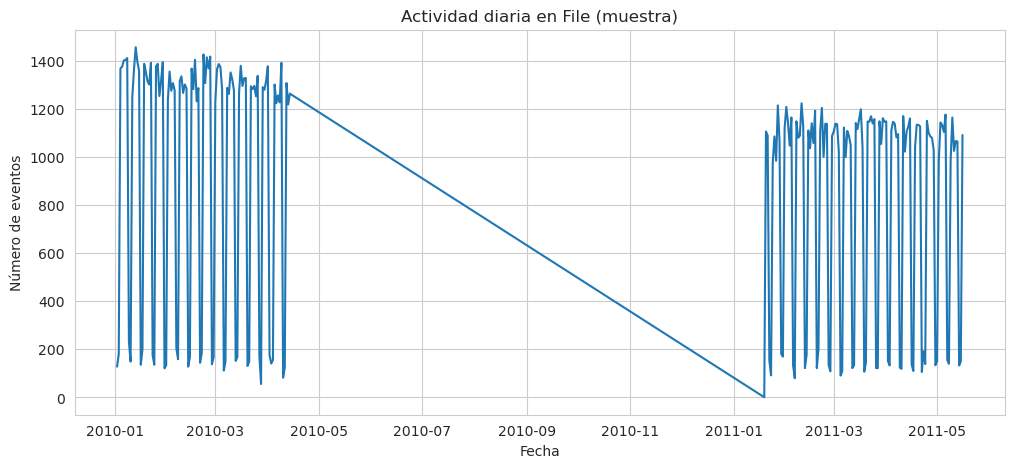

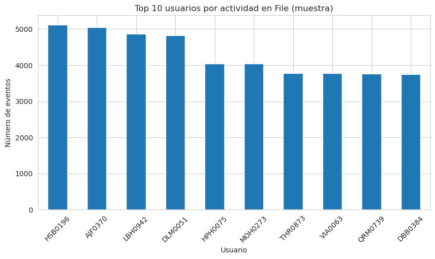

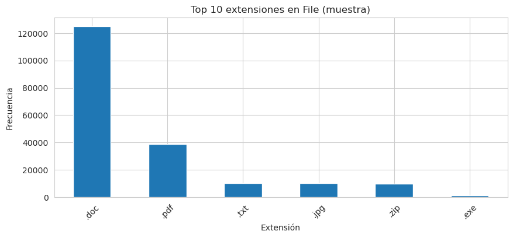

```
Resumen exploración File (muestra):
  - Registros en muestra: 195581
  - Usuarios únicos (muestra): 236
  - Rango temporal (muestra): 2010-01-02 07:23:14 a 2011-05-16 23:22:34
```

```python
# 10.2 Calidad, temporalidad y actividad preliminar
# Validacio estructural: tipos de datos, memoria y conteo de no-nulos
df_file.info()

# Reporte estandarizado de valores nulos usando la funcion auxiliar definida en 3.1
report_nulls(df_file, title='Nulos en file (muestra):')

# Rango temporal de nuestra muestra: es importante validar que la muestra aleatoria cubre un periodo representativo del dataset completo para asegurar que cualquier analisis
# temporal posterior no este sesgado por un periodo especifico
file_min = df_file['date'].min()
file_max = df_file['date'].max()
print(f'Fecha mínima (muestra): {file_min}')
print(f'Fecha máxima (muestra): {file_max}')

# Agregacio diaria para visualizar volumen de accesos a archivos en el tiempo
df_file['date_only'] = df_file['date'].dt.date
file_daily = df_file.groupby('date_only').size()
plt.figure(figsize=(12, 5))
file_daily.plot(kind='line')
plt.title('Actividad diaria en File (muestra)')
plt.xlabel('Fecha')
plt.ylabel('Número de eventos')
plt.show()

# Distribucio de usuarios con mayor interaccio con archivos
file_top_users = df_file['user'].value_counts().head(10)
plt.figure(figsize=(10, 5))
file_top_users.plot(kind='bar')
plt.title('Top 10 usuarios por actividad en File (muestra)')
plt.xlabel('Usuario')
plt.ylabel('Número de eventos')
plt.xticks(rotation=45)
plt.show()

# Extraccio de extensiones de archivo: util para detectar patrones de exfiltracion
# La expresio regular captura la última secuencia alfanumerica tras un punto
if 'filename' in df_file.columns:
    ext_series = (
        df_file['filename']
        .astype(str)
        .str.extract(r'(\.\w+)$', expand=False)
        .fillna('sin_extension')
    )
    plt.figure(figsize=(10, 4))
    ext_series.value_counts().head(10).plot(kind='bar')
    plt.title('Top 10 extensiones en File (muestra)')
    plt.xlabel('Extensión')
    plt.ylabel('Frecuencia')
    plt.xticks(rotation=45)
    plt.show()

# Síntesis de metricas clave para documentacio y comparacio cruzada
file_summary = {
    'Registros en muestra': len(df_file),
    'Usuarios únicos (muestra)': df_file['user'].nunique(),
    'Rango temporal (muestra)': f'{file_min} a {file_max}',
}
print('Resumen exploración File (muestra):')
for k, v in file_summary.items():
    print(f'  - {k}: {v}')
```

## 3.5. Dataset Psychometric (CERT r4.2)

Rasgos de personalidad Big Five (OCEAN) en tabla estática por usuario. Esta fuente aporta contexto psicométrico complementario a las señales de actividad.

```python
# 11.1 Carga, estructura y distribucion de rasgos
# Ruta centralizada en el diccionario DATASETS para garantizar trazabilidad y reproducibilidad
psy_path = DATASETS['psychometric']

# Carga del dataset psicométrico: tabla estática de rasgos Big Five por usuario
# A diferencia de los logs dinamicos, este archivo tiene 1 fila por usuario (1000 registros)
df_psy = pd.read_csv(psy_path)

# Inspeccion rapida de dimensiones y esquema: valida que tenemos cobertura completa (1000 usuarios)
print(f'Dimensiones psychometric: {df_psy.shape}')
print(f'Columnas psychometric: {df_psy.columns.tolist()}')

# Vista preliminar para validar formato de IDs y rangos esperados de los rasgos OCEAN (tipicamente 10-50)
df_psy.head()
```

```
Dimensiones psychometric: (1000, 7)
Columnas psychometric: ['employee_name', 'user_id', 'O', 'C', 'E', 'A', 'N']
```

|  | employee_name | user_id | O | C | E | A | N |
| --- | --- | --- | --- | --- | --- | --- | --- |
| 0 | Calvin Edan Love | CEL0561 | 40 | 39 | 36 | 19 | 40 |
| 1 | Christine Reagan Deleon | CRD0624 | 26 | 22 | 17 | 39 | 32 |
| 2 | Jade Felicia Caldwell | JFC0557 | 22 | 16 | 23 | 40 | 33 |
| 3 | Aquila Stewart Dejesus | ASD0577 | 40 | 48 | 36 | 14 | 37 |
| 4 | Micah Abdul Rojas | MAR0955 | 36 | 44 | 23 | 44 | 25 |

```
<class 'pandas.core.frame.DataFrame'>
RangeIndex: 1000 entries, 0 to 999
Data columns (total 7 columns):
 #   Column         Non-Null Count  Dtype
---  ------         --------------  -----
 0   employee_name  1000 non-null   object
 1   user_id        1000 non-null   object
 2   O              1000 non-null   int64
 3   C              1000 non-null   int64
 4   E              1000 non-null   int64
 5   A              1000 non-null   int64
 6   N              1000 non-null   int64
dtypes: int64(5), object(2)
memory usage: 54.8+ KB
Nulos en psychometric:
No se detectaron nulos.
Resumen estadístico OCEAN:
```

|  | O | C | E | A | N |
| --- | --- | --- | --- | --- | --- |
| count | 1000.000000 | 1000.000000 | 1000.00000 | 1000.000000 | 1000.000000 |
| mean | 33.173000 | 30.653000 | 29.19700 | 28.821000 | 29.608000 |
| std | 10.642007 | 11.291505 | 10.95647 | 11.170844 | 4.938494 |
| min | 10.000000 | 10.000000 | 10.00000 | 10.000000 | 14.000000 |
| 25% | 23.000000 | 20.000000 | 19.00000 | 19.000000 | 26.000000 |
| 50% | 36.000000 | 33.000000 | 28.00000 | 27.000000 | 29.000000 |
| 75% | 42.000000 | 40.000000 | 39.00000 | 39.000000 | 33.000000 |
| max | 50.000000 | 50.000000 | 50.00000 | 50.000000 | 49.000000 |

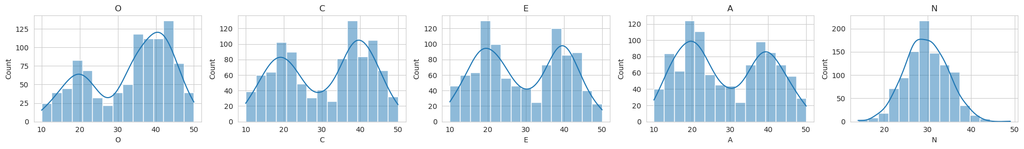

```
Resumen exploración Psychometric:
  - Registros totales: 1000
  - Usuarios únicos: 1000
  - Rasgos analizados: O, C, E, A, N
```

```python
# 11.2 Calidad y estadisticos de OCEAN
# Validacion estructural: tipos de datos, memoria y conteo de no-nulos (esperamos 0 nulos en tabla maestra)
df_psy.info()

# Reporte estandarizado de valores nulos usando funcion auxiliar (sección 3.1)
report_nulls(df_psy, title='Nulos en psychometric:')

# Definicion explicita de los rasgos Big Five para iteración consistente en visualizacion y analisis
traits = ['O', 'C', 'E', 'A', 'N'] # Openness, Conscientiousness, Extraversion, Agreeableness, Neuroticism

# Estadisticos descriptivos: media, desviacion y rangos para validar distribucion esperada de rasgos
print('Resumen estadístico OCEAN:')
display(df_psy[traits].describe())

# Visualizacio de distribuciones individuales: histogramas con KDE para detectar sesgos o multimodalidad
fig, axes = plt.subplots(1, 5, figsize=(20, 3))
for i, t in enumerate(traits):
    # KDE suaviza la distribucion para identificar patrones subyacentes más alla del conteo bruto
    sns.histplot(df_psy[t], bins=15, kde=True, ax=axes[i])
    axes[i].set_title(t)
plt.tight_layout() # Ajuste de margenes para evitar solapamiento entre subplots
plt.show()


# Síntesis de metricas clave para documentacion y comparacion cruzada con otros datasets
psy_summary = {
    'Registros totales': len(df_psy),
    # Validacion condicional de columna para robustez ante cambios de esquema futuros
    'Usuarios únicos': df_psy['user_id'].nunique() if 'user_id' in df_psy.columns else np.nan,
    'Rasgos analizados': ', '.join(traits),
}
print('Resumen exploración Psychometric:')
for k, v in psy_summary.items():
    print(f'  - {k}: {v}')
```

```python
# Verificacio de rangos validos para rasgos OCEAN: típicamente se espera que estén entre 10 y 50 en simulaciones CERT,
# aunque esto puede variar segun la configuración de la simulacion.
for trait in traits:
    min_val, max_val = df_psy[trait].min(), df_psy[trait].max()
    if not (10 <= min_val <= 50 and 10 <= max_val <= 50):
        print(f"⚠️ Alerta: {trait} fuera de rango esperado [10-50]: [{min_val}, {max_val}]")
```

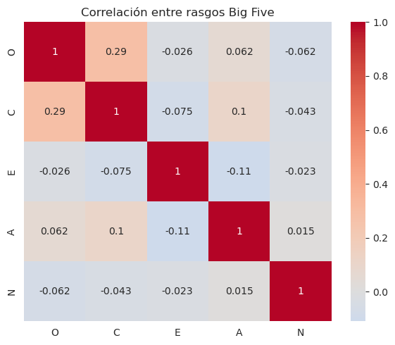

```python
# Matriz de correlacion para detectar colinealidad antes de feature engineering
plt.figure(figsize=(6, 5))
sns.heatmap(df_psy[traits].corr(), annot=True, cmap='coolwarm', center=0)
plt.title('Correlación entre rasgos Big Five')
plt.tight_layout()
plt.show()
```

```python
# NOTA SOBRE INTERDEPENDENCIA DE RASGOS OCEAN:
# El análisis de correlaciones muestra independencia casi total entre las dimensiones
# (valores cercanos a 0, salvo una leve correlación positiva entre O-C de 0.29).
#
# Implicaciones para el TFM:
# 1. Validez constructiva: Confirma que los rasgos fueron generados respetando la ortogonalidad teórica del modelo Big Five.
# 2. Integridad para Feature Engineering: La ausencia de multicolinealidad fuerte permite que los algoritmos
#    (Isolation Forest) y la explicabilidad (SHAP) evalúen la contribución marginal de cada rasgo sin distorsiones estadísticas.
# 3. Rol en el modelo: Al tratarse de variables estáticas e independientes, su integración en la matriz maestra
#    aporta información de 'línea base' psicológica sin contaminar las señales dinámicas de comportamiento.
```

```python
# NOTA M3.2: La columna 'user_id' en psychometric debe unirse con 'user' en logs dinámicos.
# Validar que df_psy['user_id'].isin(df_logon['user']).all() == True antes del merge final.
```

```python
# NOTA DE CIERRE M3.1:
# La exploración preliminar confirma que:
# 1. Todos los datasets comparten esquema base (id, date, user, pc) facilitando merge futuro
# 2. Email y File requieren procesamiento por chunks en M3.2 para evitar sesgo de submuestreo
# 3. Psychometric y LDAP son tablas dimensionales estáticas que enriquecen el perfilado conductual
# 4. La cobertura temporal (499 días) es consistente entre fuentes núcleo (Logon/Device)
#
# Próximo paso: Integración LDAP para contexto organizativo longitudinal (sección 4)
```

# 4. Contexto organizativo: snapshots mensuales LDAP

LDAP aporta la dimensión organizativa longitudinal (18 snapshots, diciembre de 2009 a mayo de 2011). El objetivo en esta fase es caracterizar estabilidad de estructura, cambios de rol/departamento/equipo/supervisión y dinámica de altas y bajas.

```python
# 12.1 Cargamos snapshots mensuales LDAP
# LDAP aporta dimension organizativa longitudinal: 18 snapshots mensuales (dic-2009 a may-2011)
# Objetivo: caracterizar estabilidad estructural, cambios de rol/departamento y dinamica de altas/bajas
ldap_dir = DATASETS['ldap_dir'] # Ruta centralizada desde diccionario DATASETS (sección 3.1)

# Filtrado de archivos CSV validos: excluimos locks temporales de Office/LibreOffice
ldap_files = sorted([p for p in ldap_dir.glob('*.csv') if not p.name.startswith('.~lock')])
print(f'Archivos LDAP detectados: {len(ldap_files)}')
for p in ldap_files[:5]:
    print(f'  - {p.name}')

# Carga iterativa: almacenamos cada snapshot en diccionario para analisis comparativo posterior
ldap_monthly = {} # Diccionario para almacenar DataFrames mensuales con clave de mes (e.g.: '2009-12')
ldap_overview_rows = [] # Lista para almacenar metricas estructurales por mes para resumen ejecutivo
for p in ldap_files:
    month = p.stem # Extraemos identificador temporal del nombre de archivo (e.g.: '2010-01')
    df_m = pd.read_csv(p)
    ldap_monthly[month] = df_m.copy() # Copiamos el DataFrame para evitar modificaciones accidentales en el original

    # Extracción de metricas estructurales por mes para resumen ejecutivo
    ldap_overview_rows.append({
        'month': month,
        'rows': len(df_m),
        'employees_unique': df_m['user_id'].nunique() if 'user_id' in df_m.columns else np.nan,
        'roles_unique': df_m['role'].nunique() if 'role' in df_m.columns else np.nan,
        'departments_unique': df_m['department'].nunique() if 'department' in df_m.columns else np.nan,
        'teams_unique': df_m['team'].nunique() if 'team' in df_m.columns else np.nan,
        'supervisor_missing': int(df_m['supervisor'].isna().sum()) if 'supervisor' in df_m.columns else np.nan,
    })

# Visualizacion de tendencias: primeros y ultimos meses para validar rango temporal completo
ldap_overview = pd.DataFrame(ldap_overview_rows).sort_values('month')
display(ldap_overview.head())
display(ldap_overview.tail())
```

```
Archivos LDAP detectados: 18
  - 2009-12.csv
  - 2010-01.csv
  - 2010-02.csv
  - 2010-03.csv
  - 2010-04.csv
```

|  | month | rows | employees_unique | roles_unique | departments_unique | teams_unique | supervisor_missing |
| --- | --- | --- | --- | --- | --- | --- | --- |
| 0 | 2009-12 | 1000 | 1000 | 42 | 22 | 38 | 1 |
| 1 | 2010-01 | 1000 | 1000 | 42 | 22 | 38 | 1 |
| 2 | 2010-02 | 989 | 989 | 42 | 22 | 38 | 1 |
| 3 | 2010-03 | 982 | 982 | 42 | 22 | 38 | 1 |
| 4 | 2010-04 | 980 | 980 | 42 | 22 | 38 | 1 |

|  | month | rows | employees_unique | roles_unique | departments_unique | teams_unique | supervisor_missing |
| --- | --- | --- | --- | --- | --- | --- | --- |
| 13 | 2011-01 | 878 | 878 | 41 | 22 | 38 | 1 |
| 14 | 2011-02 | 868 | 868 | 41 | 22 | 38 | 1 |
| 15 | 2011-03 | 857 | 857 | 41 | 22 | 38 | 1 |
| 16 | 2011-04 | 846 | 846 | 41 | 22 | 38 | 1 |
| 17 | 2011-05 | 845 | 845 | 41 | 22 | 38 | 1 |

```python
# 12.2 Validamos esquema y campos clave
# Objetivo: garantizar consistencia estructural entre snapshots para merge seguro en M3.2
schema_by_month = {m: set(df.columns) for m, df in ldap_monthly.items()}
all_cols = sorted(set().union(*schema_by_month.values()))

# Comparacio de esquemas: detectamos columnas faltantes o adicionales entre meses
schema_check = []
for m, cols in schema_by_month.items():
    missing = sorted(set(all_cols) - cols) # Columnas esperadas pero ausentes en este mes
    extra = sorted(cols - set(all_cols)) # Columnas adicionales no observadas en otros meses
    schema_check.append({
        'month': m,
        'n_columns': len(cols),
        'missing_vs_union': len(missing),
        'extra_vs_union': len(extra),
    })

schema_check_df = pd.DataFrame(schema_check).sort_values('month')
display(schema_check_df) # Validacion visual: esperamos 0 en missing/extra para todos los meses

# Cobertura de campos criticos: porcentaje de nulos en variables esenciales para integración
required_cols = ['employee_name', 'user_id', 'email', 'role', 'business_unit', 'department', 'team', 'supervisor']
coverage_rows = []
for m, df in ldap_monthly.items():
    row = {'month': m}
    for c in required_cols:
        # Calculamos % de valores faltantes solo si la columna existe en el esquema
        row[f'{c}_missing_pct'] = (df[c].isna().mean() * 100) if c in df.columns else 100.0
    coverage_rows.append(row)
coverage_df = pd.DataFrame(coverage_rows).sort_values('month')
display(coverage_df.head()) # Vista preliminar para detectar degradacion progresiva de calidad
```

|  | month | n_columns | missing_vs_union | extra_vs_union |
| --- | --- | --- | --- | --- |
| 0 | 2009-12 | 9 | 0 | 0 |
| 1 | 2010-01 | 9 | 0 | 0 |
| 2 | 2010-02 | 9 | 0 | 0 |
| 3 | 2010-03 | 9 | 0 | 0 |
| 4 | 2010-04 | 9 | 0 | 0 |
| 5 | 2010-05 | 9 | 0 | 0 |
| 6 | 2010-06 | 9 | 0 | 0 |
| 7 | 2010-07 | 9 | 0 | 0 |
| 8 | 2010-08 | 9 | 0 | 0 |
| 9 | 2010-09 | 9 | 0 | 0 |
| 10 | 2010-10 | 9 | 0 | 0 |
| 11 | 2010-11 | 9 | 0 | 0 |
| 12 | 2010-12 | 9 | 0 | 0 |
| 13 | 2011-01 | 9 | 0 | 0 |
| 14 | 2011-02 | 9 | 0 | 0 |
| 15 | 2011-03 | 9 | 0 | 0 |
| 16 | 2011-04 | 9 | 0 | 0 |
| 17 | 2011-05 | 9 | 0 | 0 |

|  | month | employee_name_missing_pct | user_id_missing_pct | email_missing_pct | role_missing_pct | business_unit_missing_pct | department_missing_pct | team_missing_pct | supervisor_missing_pct |
| --- | --- | --- | --- | --- | --- | --- | --- | --- | --- |
| 0 | 2009-12 | 0.0 | 0.0 | 0.0 | 0.0 | 0.0 | 1.400000 | 12.700000 | 0.100000 |
| 1 | 2010-01 | 0.0 | 0.0 | 0.0 | 0.0 | 0.0 | 1.400000 | 12.700000 | 0.100000 |
| 2 | 2010-02 | 0.0 | 0.0 | 0.0 | 0.0 | 0.0 | 1.415571 | 12.740142 | 0.101112 |
| 3 | 2010-03 | 0.0 | 0.0 | 0.0 | 0.0 | 0.0 | 1.425662 | 12.830957 | 0.101833 |
| 4 | 2010-04 | 0.0 | 0.0 | 0.0 | 0.0 | 0.0 | 1.428571 | 12.857143 | 0.102041 |

|  | from_month | to_month | employees_prev | employees_curr | new_entries | exits | common_users |
| --- | --- | --- | --- | --- | --- | --- | --- |
| 0 | 2009-12 | 2010-01 | 1000 | 1000 | 0 | 0 | 1000 |
| 1 | 2010-01 | 2010-02 | 1000 | 989 | 0 | 11 | 989 |
| 2 | 2010-02 | 2010-03 | 989 | 982 | 0 | 7 | 982 |
| 3 | 2010-03 | 2010-04 | 982 | 980 | 0 | 2 | 980 |
| 4 | 2010-04 | 2010-05 | 980 | 974 | 0 | 6 | 974 |

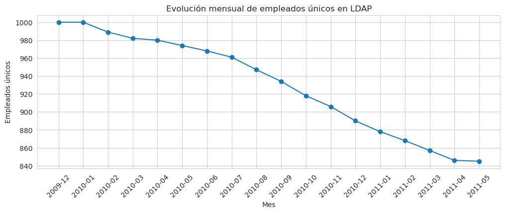

```python
# 12.3 Altas y bajas mensuales por user_id
# Objetivo: cuantificar rotación de personal para contextualizar actividad en logs dinámicos
months_sorted = sorted(ldap_monthly.keys())
turnover_rows = []

for prev_m, curr_m in zip(months_sorted[:-1], months_sorted[1:]):
    prev_ids = set(ldap_monthly[prev_m]['user_id'].dropna().astype(str))
    curr_ids = set(ldap_monthly[curr_m]['user_id'].dropna().astype(str))

    # Calculo de metricas de rotacio: entradas, salidas y permanencia
    turnover_rows.append({
        'from_month': prev_m,
        'to_month': curr_m,
        'employees_prev': len(prev_ids),
        'employees_curr': len(curr_ids),
        'new_entries': len(curr_ids - prev_ids), # Altas: usuarios nuevos en mes actual
        'exits': len(prev_ids - curr_ids),          # Bajas: usuarios que desaparecen en mes actual
        'common_users': len(prev_ids & curr_ids), # Permanencia: usuarios que se mantienen entre meses para analisis longitudinal
    })

turnover_df = pd.DataFrame(turnover_rows)
display(turnover_df.head()) # Validacio visual de dinamica organizativa

# Visualizacio de tendencia: evolucio del headcount a lo largo del periodo de estudio
plt.figure(figsize=(12, 4))
plt.plot(ldap_overview['month'], ldap_overview['employees_unique'], marker='o')
plt.xticks(rotation=45)
plt.title('Evolución mensual de empleados únicos en LDAP')
plt.xlabel('Mes')
plt.ylabel('Empleados únicos')
plt.show()
```

```python
# 12.4 Cambios de estructura organizativa en usuarios comunes
# Objetivo: detectar reasignaciones de rol/departamento que puedan explicar cambios conductuales

change_cols = ['role', 'department', 'team', 'supervisor']
change_rows = []
for prev_m, curr_m in zip(months_sorted[:-1], months_sorted[1:]):
    # Preparamos DataFrames con solo columnas relevantes y eliminamos duplicados por user_id
    prev_df = ldap_monthly[prev_m][['user_id'] + change_cols].drop_duplicates(subset=['user_id']).copy()
    curr_df = ldap_monthly[curr_m][['user_id'] + change_cols].drop_duplicates(subset=['user_id']).copy()

    # Merge para comparar estado previo vs actual de usuarios comunes
    merged = prev_df.merge(curr_df, on='user_id', suffixes=('_prev', '_curr'))
    row = {'from_month': prev_m, 'to_month': curr_m, 'users_compared': len(merged)}

    # Conteo de cambios por columna: comparamos valor previo vs actual y sumamos las diferencias
    for c in change_cols:
        left = merged[f'{c}_prev'].fillna('MISSING').astype(str)
        right = merged[f'{c}_curr'].fillna('MISSING').astype(str)
        row[f'{c}_changes'] = int((left != right).sum()) # Incrementa solo si el valor cambió
    change_rows.append(row)

org_changes_df = pd.DataFrame(change_rows)
display(org_changes_df.head())

# Sintesis de metricas LDAP para documentacion y trazabilidad del pipeline
ldap_summary = {
    'Meses LDAP procesados': len(months_sorted),
    'Primer mes': months_sorted[0] if months_sorted else None,
    'Último mes': months_sorted[-1] if months_sorted else None,
    'Campos clave evaluados': ', '.join(change_cols),
}
print('Resumen LDAP descriptivo:')
for k, v in ldap_summary.items():
    print(f'  - {k}: {v}')
```

|  | from_month | to_month | users_compared | role_changes | department_changes | team_changes | supervisor_changes |
| --- | --- | --- | --- | --- | --- | --- | --- |
| 0 | 2009-12 | 2010-01 | 1000 | 0 | 0 | 0 | 0 |
| 1 | 2010-01 | 2010-02 | 989 | 0 | 0 | 0 | 0 |
| 2 | 2010-02 | 2010-03 | 982 | 0 | 0 | 0 | 0 |
| 3 | 2010-03 | 2010-04 | 980 | 0 | 0 | 0 | 0 |
| 4 | 2010-04 | 2010-05 | 974 | 0 | 0 | 0 | 0 |

```
Resumen LDAP descriptivo:
  - Meses LDAP procesados: 18
  - Primer mes: 2009-12
  - Último mes: 2011-05
  - Campos clave evaluados: role, department, team, supervisor
```